# Climate Extremes Analysis Demo

```r
knitr::opts_chunk$set(echo = TRUE, results = FALSE, warning = FALSE, message = FALSE)
library(lubridate)
library(tidyverse)
library(here)
```

### Getting Started: set up environment

The packages we will need for this analysis are (same as for the trend demo):

- lubridate: makes it easier to work with date information and use it in plotting
- tidyverse: a suite of R packages designed to optimize working with “tidy” data. This package contains other ones, including the `ggplot2` package that helps with making nice-looking graphs!

### Reading in data

The first thing to do is to read in some data. Here, I’ve chosen the Lake Cachuma station from the National Centers for Environmental Information website: https://www.ncdc.noaa.gov/cdo-web/datatools/findstation

This is the same dataset used for the trends demo. Let’s read in the data again!

Once the data has been read in, the as.Date command then transforms the DATE field in that table into an R-formatted date array that R knows how to do things with.

We can look at the data that we’ve read in using the `head` command; this will display the first few rows of the table so we can see if everything makes sense.

```r
clim = read_csv(here("CachumaLake_NCDC_USC00041253.csv"))
head(clim)

date=as.Date(clim$DATE)
```

### Extremes metrics: number of freezing days

Once the ifelse statement has been completed, the next thing the code below does is make use of the `group_by` and `summarize` functions to count the number of freezing days! This is done in two steps:

The times that go along with the (now yearly!) number of freezing days are calculated by finding all the unique years in the dataset (`unique(year(date))`) and assigned to another new field in the data table called `dt`.

Finally, the number of freezing days is plotted using ggplot, as we did for the trends demo.

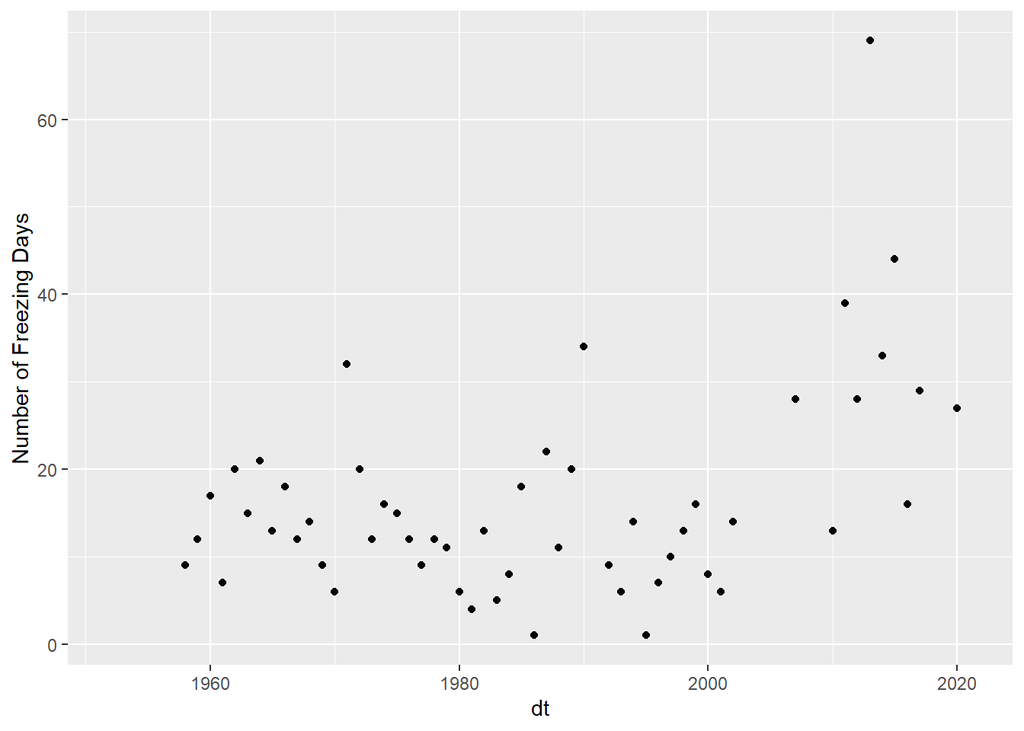

```r
clim$freeze = ifelse(clim$TMIN <= 32, 1, 0)
clim.wfrdata = clim %>% group_by(year(date)) %>% summarize(ndayfr=sum(freeze))
clim.wfrdata$dt = unique(year(date))

ggplot(clim.wfrdata, aes(dt, ndayfr))+geom_point()+labs(y="Number of Freezing Days")
```

Note that the trends in mean-state and extreme metrics often go together: from last time, recall that there was a trend toward decreasing minimum daily temperature. How does that affect the frequency of occurrence of freezing days?

### Extremes metrics: hottest day of the year

Looking at the warm end of the temperature distribution, we can now look for trends in the temperature during the hottest day of the year.

This is accomplished using a similar methodology as we used for the freezing days above; again, the group_by function groups the data according to year, then the temperature associated with the hottest day is calculated by applying the `max` function to the `TMAX` field in the data table.

[output not shown]

### Extremes metrics: return periods

In lecture, we discussed the concept of return periods and return levels. Here is how you calculate these things with real data!

We’ll specify some reasonable threshold for daily precipitation: say, 1 inch/day. To calculate the return period associated with that threshold, what we do is the following: * Use `ifelse` to create a field called “flood” that is 1 when precipitation is above the threshold, and 0 otherwise * Store the total number of years by first identifying the total number of unique years, then calculating the length of the array where those unique years are listed

The return period is then the number of years (plus one to include the starting year) divided by the number of times the threshold exceedance has actually occurred. (Note: we have to use the `na.rm=TRUE` flag to prevent NA entries from seeming like they are contributing to the count of threshold exceedances!)

```r
clim$flood = ifelse(clim$PRCP >= 1, 1, 0)
nyrs=length(unique(year(date)))

retper=(nyrs+1)/sum(clim$flood,na.rm=TRUE)
```

Another note: return *levels* are somewhat more complicated to calculate, since they require fitting the underlying distribution of the data… there are lots of resources out there if you need them though!